# Z-score, Korelasi, dan Regresi

Statistik Pendidikan (AUD0331)

Indira Puteri Kinasih

indiraputeri@uinmataram.ac.id

Universitas Islam Negeri Mataram

## Tujuan Pembelajaran

Setelah mengikuti pembelajaran, mahasiswa mampu:

- menjelaskan makna **z-score** dan menghitungnya;
- menginterpretasikan posisi relatif suatu nilai;
- membaca hubungan antara dua variabel melalui **crosstab** dan **scatterplot**;
- menjelaskan makna **korelasi Pearson**;
- memahami ide dasar **regresi linear**;
- menginterpretasikan persamaan garis regresi;
- menjelaskan kualitas model regresi secara sederhana;
- memahami bahwa **korelasi tidak selalu berarti sebab-akibat**.

# Bagian 1

## Z-score

### Mengapa kita membutuhkan z-score?

Kita sudah mempelajari:

- ukuran pemusatan → *di mana pusat data?*
- ukuran penyebaran → *seberapa bervariasi data?*

Pertanyaan berikutnya:

> **Bagaimana mengetahui posisi suatu nilai dibandingkan dengan kelompoknya?**

Contoh:

- Anak A mendapat skor 80.
- Anak B mendapat skor 80.

Apakah posisi kedua anak tersebut sama?

**Belum tentu.**

Jika mereka berasal dari kelompok dengan rata-rata dan penyebaran yang berbeda, maka posisi relatif mereka juga dapat berbeda.

## Konsep Z-score

Z-score menunjukkan:

> **berapa standar deviasi suatu nilai berada di atas atau di bawah rata-rata.**

Untuk populasi:

$$z=\frac{x-\mu}{\sigma}$$

Untuk data sampel:

$$z=\frac{x-\bar{x}}{s}$$

Keterangan:

| Simbol | Makna |
| --- | --- |
| $x$ | nilai yang diamati |
| $\mu$ | rata-rata populasi |
| $\sigma$ | standar deviasi populasi |
| $\bar{x}$ | rata-rata sampel |
| $s$ | standar deviasi sampel |
| $z$ | skor baku |

## Cara Membaca Z-score

| Z-score | Interpretasi |
| --- | --- |
| $z=0$ | tepat pada rata-rata |
| $z>0$ | di atas rata-rata |
| $z<0$ | di bawah rata-rata |
| $z=1$ | 1 SD di atas rata-rata |
| $z=-1$ | 1 SD di bawah rata-rata |
| $z=2$ | 2 SD di atas rata-rata |
| $z=-2$ | 2 SD di bawah rata-rata |

Yang penting bukan hanya menghitung.

> **Z-score harus dibaca dalam konteks data.**

## Contoh 1: Skor Kemampuan Bahasa

Misalkan skor kemampuan bahasa anak:

$$\bar{x}=70,\qquad s=10$$

Seorang anak memperoleh skor:

$$x=85$$

Maka:

$$z=\frac{85-70}{10}=1.5$$

### Interpretasi

Skor anak tersebut berada:

> **1,5 standar deviasi di atas rata-rata kelompok.**

Bukan berarti anak tersebut memperoleh “nilai 1,5”.

## Contoh 2

Rata-rata skor adalah 70 dan standar deviasi 10.

Seorang anak memperoleh skor 55.

$$z=\frac{55-70}{10}=-1.5$$

Artinya:

> Skor anak tersebut berada **1,5 standar deviasi di bawah rata-rata kelompok**.

Perhatikan tanda negatif.

**Negatif tidak berarti “nilai buruk”.**

Tanda negatif hanya menunjukkan posisi **di bawah rata-rata**.

## Membandingkan 2 Anak dari 2 kelompok data berbeda

Dua anak memperoleh skor:

- Anak A = 80
- Anak B = 75

Misalkan:

|  | Rata-rata | SD | Skor |
| --- | --- | --- | --- |
| Anak A | 70 | 10 | 80 |
| Anak B | 60 | 5 | 75 |

Z-score:

$$z_A=\frac{80-70}{10}=1$$

$$z_B=\frac{75-60}{5}=3$$

### Pertanyaan

Siapa yang memiliki posisi relatif lebih tinggi?

**Anak B.**

Meskipun skor mentah Anak A lebih tinggi, posisi relatif Anak B jauh lebih tinggi dibandingkan kelompoknya.

## Z-score sebagai Skor Baku

Z-score memungkinkan kita:

- membandingkan nilai dari kelompok yang berbeda;
- melihat posisi relatif seseorang;
- mengidentifikasi nilai yang relatif jauh dari rata-rata;
- mengubah skala yang berbeda menjadi skala yang sama.

### Ide utama

> **Skor mentah memberi tahu “berapa nilainya”.**

> **Z-score memberi tahu “di mana posisinya dalam kelompok”.**

## Latihan

Suatu kelas memiliki:

$$\bar{x}=75,\qquad s=8$$

Tiga anak memperoleh skor:

| Anak | Skor |
| --- | --- |
| A | 75 |
| B | 83 |
| C | 59 |

Hitung z-score masing-masing.

Kemudian jelaskan:

1. siapa yang berada pada rata-rata?
2. siapa yang paling jauh dari rata-rata?
3. apa arti tanda positif dan negatif?

# Bagian 2

## Melihat Hubungan Dua Variabel

Selama ini kita banyak membahas **satu variabel**.

Contoh:

- skor kemampuan bahasa;
- tinggi badan;
- waktu belajar;
- kehadiran.

Sekarang kita mulai melihat **dua variabel secara bersamaan**.

Contoh pertanyaan:

> Apakah anak yang lebih sering hadir cenderung memperoleh skor yang lebih tinggi?

atau

> Apakah waktu belajar berkaitan dengan skor perkembangan anak?

## Dua Variabel Kategorik

Jika kedua variabel berbentuk kategori, kita dapat menggunakan:

### **Crosstab / Tabel Kontingensi**

Contoh:

- Aktivitas belajar: tinggi / rendah
- Capaian: mencapai / belum mencapai

| Aktivitas | Mencapai | Belum | Total |
| --- | --- | --- | --- |
| Tinggi | 24 | 6 | 30 |
| Rendah | 12 | 18 | 30 |
| **Total** | **36** | **24** | **60** |

## Bagaimana Membacanya?

Dari tabel:

- 24 dari 30 anak dengan aktivitas tinggi mencapai target;
- 12 dari 30 anak dengan aktivitas rendah mencapai target.

Secara proporsi:

$$\frac{24}{30}=80\%$$

sedangkan:

$$\frac{12}{30}=40\%$$

### Pertanyaan

Apakah terdapat pola hubungan antara aktivitas belajar dan pencapaian?

**Ya, terlihat adanya perbedaan proporsi.**

Tetapi…

> Apakah aktivitas belajar **menyebabkan** pencapaian?

**Belum dapat disimpulkan.**

## Dua Variabel Numerik

Jika kedua variabel berupa angka, kita dapat menggunakan:

### **Scatterplot**

Misalnya:

- $x$ = waktu belajar
- $y$ = skor perkembangan

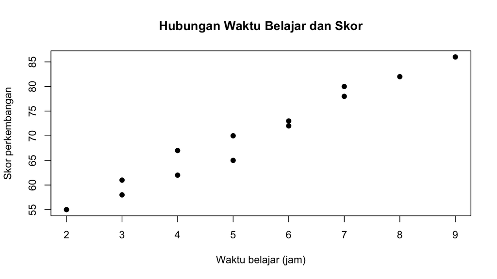

## Apa yang Kita Cari dari Scatterplot?

Perhatikan:

- arah hubungan;
- kekuatan pola;
- bentuk hubungan;
- pencilan (*outlier*);
- apakah hubungan tampak linear.

### Tiga kemungkinan sederhana

**Positif**

> semakin besar X, Y cenderung meningkat.

**Negatif**

> semakin besar X, Y cenderung menurun.

**Tidak jelas**

> tidak tampak pola hubungan yang konsisten.

# Bagian 3

## Korelasi Pearson

Scatterplot membantu kita **melihat** hubungan.

Korelasi Pearson membantu kita **mengukur kekuatan dan arah hubungan linear**.

Koefisien korelasi Pearson dilambangkan:

$$r$$

Nilainya berada pada:

$$-1\leq r\leq1$$

Rumusnya adalah:

$$r =
\frac{
\sum (x_i-\bar{x})(y_i-\bar{y})
}{
\sqrt{
\sum (x_i-\bar{x})^2
\sum (y_i-\bar{y})^2
}
}$$
- dengan:

$(x_i, y_i)$ = nilai pengamatan ke-$(i)$;

$\bar{x}, \bar{y}$ = rata-rata masing-masing variabel.

## Cara Membaca $r$

| Nilai $r$ | Arah hubungan |
| --- | --- |
| mendekati +1 | positif kuat |
| mendekati 0 | hubungan linear lemah/tidak ada |
| mendekati −1 | negatif kuat |

Contoh:

$$r=0.82$$

→ hubungan linear positif yang kuat.

$$r=-0.75$$

→ hubungan linear negatif yang kuat.

$$r=0.08$$

→ hampir tidak ada hubungan linear.

## Korelasi Bukan Sekadar Angka

Misalkan diperoleh:

$$r=0.70$$

Interpretasi yang tepat:

> Terdapat hubungan linear positif yang cukup kuat antara kedua variabel.

Interpretasi yang **tidak tepat**:

> Anak yang belajar lebih lama pasti memiliki kemampuan lebih tinggi.

Mengapa?

Karena korelasi:

- tidak menunjukkan sebab-akibat;
- tidak menjelaskan variabel lain;
- hanya mengukur hubungan linear.

## Aktivitas: Tebak Korelasi

Perhatikan tiga situasi berikut.

### A

Anak dengan waktu belajar lebih tinggi cenderung memiliki skor lebih tinggi.

### B

Anak dengan waktu belajar lebih tinggi cenderung memiliki skor lebih rendah.

### C

Tidak terlihat pola yang jelas.

Prediksikan:

$$r_A \quad r_B \quad r_C$$

Apakah masing-masing:

- positif?
- negatif?
- mendekati nol?

## Pearson’s $r$ dengan Excel

- Misal data yang hendak dihitung korelasinya ada pada kolom A dan B, baris 2 hingga 14, maka rumus excel yang dapat digunakan adalah:

`=CORREL(A2:A14,B2:B14)`

atau

`=PEARSON(A2:A14,B2:B14)`

## Pearson’s $r$ dengan R

Misalkan data:

```
   StudyTime Score
1          2    55
2          3    58
3          3    61
4          4    62
5          4    67
6          5    65
7          5    70
8          6    73
9          6    72
10         7    78
11         7    80
12         8    82
13         9    86
```

Korelasi dapat dihitung dengan:

```r
cor(
  study$StudyTime,
  study$Score
)
```

```
[1] 0.9822112
```

- Atau:

```r
cor.test(
  study$StudyTime,
  study$Score
)
```

```
    Pearson's product-moment correlation

data:  study$StudyTime and study$Score
t = 17.348, df = 11, p-value = 2.444e-09
alternative hypothesis: true correlation is not equal to 0
95 percent confidence interval:
 0.9398665 0.9948173
sample estimates:
      cor
0.9822112
```

- interpretasinya:

| Informasi | Hasil | Interpretasi |
| --- | --- | --- |
| Pearson’s $r$ | 0.982 | Hubungan positif sangat kuat |
| $p$-value | < 0.001 | Hubungan signifikan secara statistik |
| 95% CI | [0.940; 0.995] | Korelasi diperkirakan tetap positif |
| Kesimpulan | — | Waktu belajar berkaitan dengan skor yang lebih tinggi |

Untuk saat ini, fokus pada:

> **arah dan kekuatan hubungan.**

# Bagian 4

## Regresi Linear

Korelasi menjawab:

> **“Seberapa kuat hubungan X dan Y?”**

Regresi memberikan pertanyaan tambahan:

> **“Bagaimana kita dapat menggunakan X untuk memperkirakan Y?”**

Misalnya:

> Apakah skor perkembangan dapat diperkirakan berdasarkan waktu belajar?

## Mencari Garis Regresi

Bentuk sederhana garis regresi:

$$\hat{y}=b_0+b_1x$$

Keterangan:

- $\hat{y}$ = nilai Y yang diprediksi;
- $b_0$ = intercept;
- $b_1$ = slope;
- $x$ = variabel prediktor.

## Apa Arti Slope?

Misalkan diperoleh:

$$\hat{y}=48+4x$$

Artinya:

> setiap peningkatan **1 jam waktu belajar** berkaitan dengan peningkatan prediksi skor sebesar **4 poin**.

Perhatikan kata:

### **“prediksi”**

bukan:

### **“pasti meningkat 4 poin”**

## Apa Arti Intercept?

Pada:

$$\hat{y}=48+4x$$

nilai intercept adalah:

$$b_0=48$$

Secara matematis, ketika:

$$x=0$$

maka:

$$\hat{y}=48$$

Tetapi interpretasi substantif harus hati-hati.

> Apakah waktu belajar 0 jam merupakan kondisi yang masuk akal?

Jika tidak, intercept mungkin hanya diperlukan untuk membentuk garis regresi.

## Menentukan Prediksi

Misalkan:

$$\hat{y}=48+4x$$

Jika seorang anak belajar 5 jam:

$$\hat{y}=48+4(5)$$

$$\hat{y}=68$$

Jadi skor yang diprediksi adalah:

**68**

## Garis Regresi pada Scatterplot

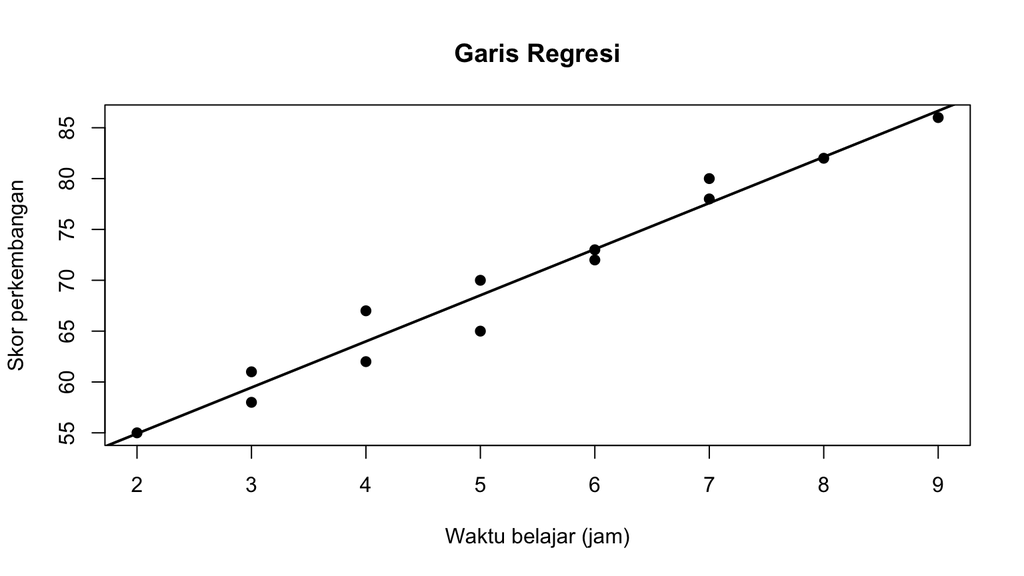

Garis tersebut merupakan garis yang:

> **meminimalkan jumlah kuadrat selisih antara nilai aktual dan nilai prediksi.**

# Bagian 5

## Seberapa Baik Garis Regresi?

Tidak semua garis regresi memberikan prediksi yang sama baiknya.

Pertanyaan berikutnya:

> **Seberapa baik model menjelaskan variasi pada Y?**

Salah satu ukuran yang sering digunakan adalah:

$$R^2$$

## Koefisien Determinasi

Misalkan:

$$R^2=0.64$$

Interpretasi sederhananya:

> Sekitar **64% variasi pada Y dalam data dapat dijelaskan oleh model yang menggunakan X**.

Sedangkan sekitar:

$$100\%-64\%=36\%$$

berada di luar penjelasan model tersebut.

## Jangan Salah Menafsirkan $R^2$

Jika:

$$R^2=0.64$$

bukan berarti:

> “X menyebabkan 64% perubahan Y.”

Yang dapat dikatakan:

> Model dengan X memiliki kemampuan menjelaskan sekitar 64% variasi Y pada data tersebut.

Masih mungkin terdapat:

- variabel lain;
- kesalahan pengukuran;
- faktor lingkungan;
- karakteristik individu;
- faktor keluarga;
- faktor guru;
- faktor sekolah.

## Residual

Regresi menghasilkan:

- nilai aktual;
- nilai prediksi;
- selisih antara keduanya.

Selisih tersebut disebut:

### **residual**

$$e=y-\hat{y}$$

Jika:

- aktual = 75
- prediksi = 70

maka:

$$e=75-70=5$$

Model **underestimate** sebesar 5 poin.

# Bagian 6

## Korelasi ≠ Kausalitas

Ini adalah salah satu prinsip terpenting dalam membaca data pendidikan.

Misalkan ditemukan:

$$r=0.75$$

antara:

> waktu menggunakan media pembelajaran digital

dan

> skor perkembangan anak.

Apakah kita boleh menyimpulkan:

> “Media digital meningkatkan perkembangan anak”?

**Belum tentu.**

## Mengapa?

Mungkin ada variabel ketiga.

Misalnya:

**kondisi sosial ekonomi keluarga**

dapat berkaitan dengan:

- akses terhadap perangkat digital;
- kualitas lingkungan belajar;
- dukungan orang tua;
- skor perkembangan anak.

Sehingga hubungan yang kita lihat dapat dipengaruhi oleh faktor lain.

## Contoh Lain

Misalkan ditemukan:

> semakin banyak anak membawa buku ke sekolah, semakin tinggi skor literasinya.

Apakah membawa buku menyebabkan kemampuan literasi meningkat?

Belum tentu.

Mungkin anak yang:

- memiliki kebiasaan membaca;
- mendapat dukungan orang tua;
- memiliki akses buku di rumah;

lebih mungkin membawa buku **dan** memiliki kemampuan literasi yang lebih tinggi.

## Tiga Pertanyaan Saat Membaca Hubungan

Ketika menemukan hubungan antara dua variabel, tanyakan:

### 1. Apa polanya?

Positif, negatif, atau tidak jelas?

### 2. Seberapa kuat?

Apakah hubungan lemah atau kuat?

### 3. Apakah hubungan itu kausal?

Apakah kita memiliki desain penelitian yang memungkinkan kesimpulan sebab-akibat?

# Bagian 7

## Studi Kasus: Data Pendidikan

Kita akan menggunakan contoh sederhana.

Misalkan kita memiliki data:

| Anak | Kehadiran (%) | Waktu Belajar | Skor |
| --- | --- | --- | --- |
| A | 95 | 8 | 86 |
| B | 90 | 6 | 78 |
| C | 80 | 5 | 72 |
| D | 75 | 3 | 65 |
| E | 98 | 9 | 91 |
| F | 70 | 2 | 60 |
| G | 85 | 6 | 75 |
| H | 92 | 7 | 82 |

## Pertanyaan 1 — Z-score

Rata-rata skor:

$$\bar{x}=76.1$$

Misalkan:

$$s=10.2$$

Hitung z-score untuk anak E dengan skor 91.

Kemudian interpretasikan.

## Pertanyaan 2 — Scatterplot

Buat scatterplot:

- X = Waktu Belajar
- Y = Skor

Kemudian jawab:

1. Bagaimana arah hubungan?
2. Apakah pola terlihat linear?
3. Apakah terdapat pencilan?
4. Apakah hubungan terlihat kuat?

## Pertanyaan 3 — Pearson’s $r$

Hitung:

$$r$$

Kemudian tuliskan interpretasi dalam **satu kalimat**.

Gunakan struktur:

> “Terdapat hubungan linear … antara … dan …”

Hindari langsung menggunakan kata:

> “menyebabkan”.

## Pertanyaan 4 — Regresi

Bangun model:

$$Score \sim StudyTime$$

Kemudian tentukan:

- intercept;
- slope;
- persamaan regresi;
- prediksi skor jika waktu belajar = 7 jam.

## Pertanyaan 5 — Kualitas Model

Perhatikan:

$$R^2$$

Kemudian jawab:

> Seberapa besar variasi skor yang dapat dijelaskan oleh waktu belajar melalui model tersebut?

Lalu tuliskan:

> “Model ini belum menjelaskan seluruh variasi karena …”

# Bagian 8: Contoh Regresi dengan R dan jamovi

## Mengenal Dataset CASchools

- Dataset **CASchools** memuat informasi tentang kinerja tes, karakteristik sekolah, dan latar belakang demografis siswa di California, Amerika Serikat.
  - Jumlah observasi: 420 distrik sekolah
  - Periode data: 1998–1999
  - Jenjang: K–6 dan K–8
  - Sumber: California Department of Education
  - Referensi: Stock dan Watson, *Introduction to Econometrics*
- Dataset ini tersedia dalam paket R `AER` dan dapat diunduh dalam format CSV.

**Sumber data:**

- [Dokumentasi CASchools pada paket AER](https://www.rdocumentation.org/packages/AER/versions/1.2-16/topics/CASchools)
- [Unduh dataset CASchools dalam format CSV](https://vincentarelbundock.github.io/Rdatasets/csv/AER/CASchools.csv)
- Dataset ini merupakan data observasional. Analisis regresi digunakan untuk mempelajari hubungan antarvariabel, bukan untuk langsung menyimpulkan hubungan sebab-akibat.

## Menyiapkan Data

- Dataset CASchools dapat diakses melalui paket `AER`.

```r
# Instalasi dilakukan satu kali
# install.packages("AER")

# Memuat paket
library(AER)

# Memanggil dataset
data("CASchools")

# Membuat variabel analisis
CASchools$STRatio <- CASchools$students / CASchools$teachers

CASchools$score <- (CASchools$read + CASchools$math) / 2

# Memilih variabel yang digunakan
CASchools <- CASchools[
  , c("score", "STRatio", "lunch", "expenditure")
]

head(CASchools)
```

```
   score  STRatio   lunch expenditure
1 690.80 17.88991  2.0408    6384.911
2 661.20 21.52466 47.9167    5099.381
3 643.60 18.69723 76.3226    5501.955
4 647.70 17.35714 77.0492    7101.831
5 640.85 18.67133 78.4270    5235.988
6 605.55 21.40625 86.9565    5580.147
```

### Variabel yang digunakan

| Variabel | Keterangan |
| --- | --- |
| `score` | Rata-rata skor membaca dan matematika |
| `STRatio` | Rasio jumlah siswa terhadap jumlah guru |
| `lunch` | Persentase siswa yang memenuhi syarat makan siang bersubsidi |
| `expenditure` | Pengeluaran per siswa |

### Menyimpan data untuk jamovi

```r
write.csv(
  CASchools,
  "CASchools_jamovi.csv",
  row.names = FALSE
)
```

File `CASchools_jamovi.csv` dapat dibuka langsung di jamovi.

## Scatterplot

Sebelum melakukan regresi, kita dapat melihat hubungan antara dua variabel melalui scatterplot.

Misalnya, hubungan antara rasio siswa-guru dan skor sekolah.

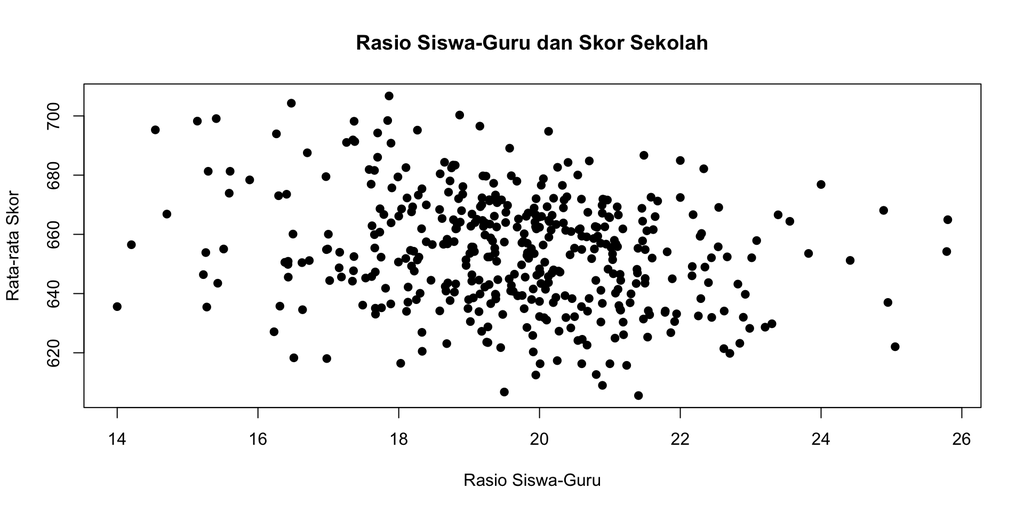

```r
plot(
  CASchools$STRatio,
  CASchools$score,
  pch = 19,
  xlab = "Rasio Siswa-Guru",
  ylab = "Rata-rata Skor",
  main = "Rasio Siswa-Guru dan Skor Sekolah"
)
```

**Pertanyaan:**

- Bagaimana arah hubungan yang terlihat?
- Apakah hubungan tersebut tampak linear?
- Apakah terdapat titik yang menyimpang dari pola umum?

## Pearson’s $r$

Korelasi Pearson digunakan untuk mengukur arah dan kekuatan hubungan linear antara dua variabel numerik.

```r
cor(
  CASchools$STRatio,
  CASchools$score
)
```

```
[1] -0.2263627
```

Untuk memperoleh pengujian statistik:

```r
cor.test(
  CASchools$STRatio,
  CASchools$score
)
```

```
    Pearson's product-moment correlation

data:  CASchools$STRatio and CASchools$score
t = -4.7513, df = 418, p-value = 2.783e-06
alternative hypothesis: true correlation is not equal to 0
95 percent confidence interval:
 -0.3152213 -0.1335696
sample estimates:
       cor
-0.2263627
```

**Interpretasi:**

- $r>0$: hubungan positif.
- $r<0$: hubungan negatif.
- $r$ mendekati 0: hubungan linear lemah.
- $|r|$ mendekati 1: hubungan linear kuat.

> Korelasi tidak menunjukkan bahwa satu variabel menyebabkan perubahan pada variabel lainnya.

## Regresi Linear Berganda

Kita ingin mengetahui apakah rasio siswa-guru, persentase siswa penerima subsidi makan siang, dan pengeluaran per siswa berkaitan dengan skor sekolah.

Model regresi:

$$\text{Score}_i =
\beta_0 +
\beta_1\text{STRatio}_i +
\beta_2\text{Lunch}_i +
\beta_3\text{Expenditure}_i +
\varepsilon_i$$

### Menjalankan regresi di R

```r
model <- lm(
  score ~ STRatio + lunch + expenditure,
  data = CASchools
)

summary(model)
```

```
Call:
lm(formula = score ~ STRatio + lunch + expenditure, data = CASchools)

Residuals:
    Min      1Q  Median      3Q     Max
-34.190  -5.656   0.110   5.694  33.481

Coefficients:
              Estimate Std. Error t value Pr(>|t|)
(Intercept)  6.706e+02  9.562e+00  70.132  < 2e-16 ***
STRatio     -3.991e-01  3.009e-01  -1.326 0.185497
lunch       -6.016e-01  1.650e-02 -36.463  < 2e-16 ***
expenditure  3.439e-03  8.914e-04   3.858 0.000132 ***
---
Signif. codes:  0 '***' 0.001 '**' 0.01 '*' 0.05 '.' 0.1 ' ' 1

Residual standard error: 9.072 on 416 degrees of freedom
Multiple R-squared:  0.7749,    Adjusted R-squared:  0.7733
F-statistic: 477.4 on 3 and 416 DF,  p-value: < 2.2e-16
```

### Membaca output/luaran regresi

Perhatikan bagian berikut:

[output not shown]

**Pertanyaan analisis:**

1. Variabel mana yang memiliki hubungan signifikan secara statistik dengan skor?
2. Bagaimana arah hubungan masing-masing prediktor?
3. Berapa proporsi variasi skor yang dijelaskan oleh model?
4. Apakah hasil ini cukup untuk menyatakan bahwa prediktor menyebabkan perubahan skor?

## Regresi Linear Berganda dengan jamovi

### 1. Membuka dataset

- Buka jamovi.
- Pilih **Open → This PC → Browse**.
- Pilih file `CASchools_jamovi.csv`.

Pastikan variabel berikut memiliki tipe pengukuran **Continuous**:

- `score`
- `STRatio`
- `lunch`
- `expenditure`

### 2. Menjalankan regresi

Pilih:

**Analyses → Regression → Linear Regression**

Kemudian:

- Masukkan `score` ke **Dependent Variable**.
- Masukkan `STRatio`, `lunch`, dan `expenditure` ke **Covariates**.

Pada bagian **Model Fit**, tampilkan:

- $R^2$
- Adjusted $R^2$

Pada bagian **Model Coefficients**, tampilkan:

- Estimate
- Standard Error
- $t$
- $p$

### 3. Membaca hasil

| Output | Pertanyaan |
| --- | --- |
| $R^2$ | Berapa proporsi variasi skor yang dijelaskan model? |
| Koefisien regresi | Bagaimana perubahan skor ketika prediktor meningkat satu satuan, dengan prediktor lain tetap? |
| $p$-value | Apakah terdapat bukti statistik bahwa koefisien berbeda dari nol? |

**Bandingkan hasil R dan jamovi.**

Apakah koefisien regresi, $R^2$, dan nilai $p$ yang diperoleh dari kedua perangkat lunak sama?

# Bagian 9

## Bagaimana Menulis Interpretasi?

Hindari hanya menulis:

> “r = 0.85.”

Itu belum merupakan interpretasi.

Gunakan pola:

> **Hasil menunjukkan terdapat hubungan linear positif yang kuat antara waktu belajar dan skor.**

Untuk regresi:

> **Setiap peningkatan satu jam waktu belajar berkaitan dengan peningkatan skor yang diprediksi sebesar … poin.**

Untuk $R^2$:

> **Model menjelaskan sekitar …% variasi skor berdasarkan waktu belajar.**

## Kesalahan yang Perlu Dihindari

### ❌ “Waktu belajar menyebabkan skor meningkat.”

Jika penelitian hanya observasional, kesimpulan ini terlalu jauh.

### ✓

> “Waktu belajar memiliki hubungan positif dengan skor.”

### ❌ “Korelasi 0,80 berarti 80%.”

Tidak tepat.

### ✓

> “$r=0.80$ menunjukkan hubungan linear positif yang kuat.”

### ❌ “R² = 0,64 berarti X menjelaskan 64% penyebab Y.”

Tidak tepat.

### ✓

> “$R^2=0.64$ menunjukkan model menjelaskan sekitar 64% variasi Y.”

# Aktivitas Kelompok

## Membaca Data Pendidikan

Dalam kelompok kecil, lakukan:

### 1. Z-score

Pilih satu variabel numerik.

Hitung z-score untuk:

- satu nilai di bawah rata-rata;
- satu nilai di atas rata-rata.

### 2. Scatterplot

Pilih dua variabel numerik.

Buat scatterplot dan jelaskan polanya.

### 3. Korelasi

Hitung Pearson’s $r$.

Interpretasikan arah dan kekuatannya.

### 4. Regresi

Bangun regresi sederhana.

Tuliskan:

- persamaan;
- slope;
- prediksi;
- $R^2$.

### 5. Kritik

Jawab:

> **Apa yang tidak dapat kita simpulkan dari analisis ini?**

# Diskusi Kelas

## Mana yang Lebih Penting?

Bayangkan dua hasil penelitian.

### Penelitian A

$$r=0.82$$

tetapi peneliti hanya memiliki data observasional.

### Penelitian B

$$r=0.45$$

tetapi penelitian menggunakan desain eksperimen yang baik.

### Pertanyaan

Mana yang lebih kuat untuk mendukung klaim:

> **“X menyebabkan perubahan pada Y”?**

# Pertanyaan Penutup

Sebelum menyimpulkan suatu hubungan dari data pendidikan, tanyakan:

> **Apa yang sebenarnya ditunjukkan oleh data?**

dan

> **Apa yang belum dapat kita simpulkan?**

Statistik bukan hanya tentang memperoleh angka.

**Statistik adalah tentang membuat kesimpulan yang sesuai dengan bukti.**

# Tugas Singkat

Gunakan satu dataset pendidikan.

Pilih:

- **1 variabel numerik** untuk analisis z-score;
- **2 variabel numerik** untuk scatterplot, korelasi, dan regresi;
- **2 variabel kategorik** jika tersedia untuk crosstab.

Laporkan:

1. satu contoh z-score dan interpretasinya;
2. satu scatterplot;
3. nilai Pearson’s $r$ dan interpretasinya;
4. persamaan regresi;
5. nilai $R^2$ dan interpretasinya;
6. **satu paragraf tentang batasan kesimpulan** yang dapat dibuat dari analisis tersebut.